# Stream Segmentation and Drawdown at the Stream

```r
library(isw)
library(units)
library(tibble)
library(dplyr)
```

```r
library(ggplot2)
library(sf)
```

## Purpose

The apportioned drawdown model represents stream depletion as injection at one point per modeled stream segment. A zero-diameter point well has an unbounded analytical response at zero distance and can therefore produce an artificially large recovery value at an observation point on the stream.

`get_apportioned_aquifer_drawdown()` regularizes this response by assigning each injection well an effective diameter equal to the segment's actual `represented_length`. The response is consequently held constant inside a radius of half that length. This vignette examines the remaining sensitivity to stream-segment spacing:

- at several fixed observation points on the stream; and
- along perpendicular transects extending away from the stream.

The model reports water-level change, not absolute hydraulic head. Therefore, `aquifer_drawdown = 0` is the relevant constant-head boundary condition at the stream. The effective-diameter approach limits a numerical artifact but does not enforce that boundary condition. A nonzero result at the stream is a boundary residual and motivates a future coupled solution for the injection rates.

## Construct a controlled straight-stream example

A straight stream makes distance from the boundary unambiguous. The pumping well is 400 m east of the stream, and the 2 km stream is long enough to reduce end effects near the observation transects. All coordinates are in meters in a projected CRS.

```r
analysis_crs <- 32615

pumping_wells <- st_as_sf(
  tibble(
    pump_id = "pump_1",
    x = 400,
    y = 0,
    K = set_units(10, "m/day"),
    D = set_units(30, "m"),
    V = 0.15,
    well_diam = set_units(0.3, "m")
  ),
  coords = c("x", "y"),
  crs = analysis_crs
)

stream_reaches <- st_sf(
  reach_id = "straight_stream",
  geometry = st_sfc(
    st_linestring(matrix(c(0, -1000, 0, 1000), ncol = 2, byrow = TRUE)),
    crs = analysis_crs
  )
)

pumping_schedules <- tibble(
  t = set_units(c(0, 180), "days"),
  pump_1 = set_units(c(500, 0), "m^3/day")
)
evaluation_times <- set_units(c(30, 90, 180), "days")
injection_times <- set_units(seq(10, 170, by = 10), "days")
```

## Place observations on the stream and along transects

The fixed on-stream locations do not depend on the segmentation. This avoids moving the diagnostic points when segment spacing changes. Three transects start at the stream and extend toward the pumping well. Their zero-distance points are also on-stream observations.

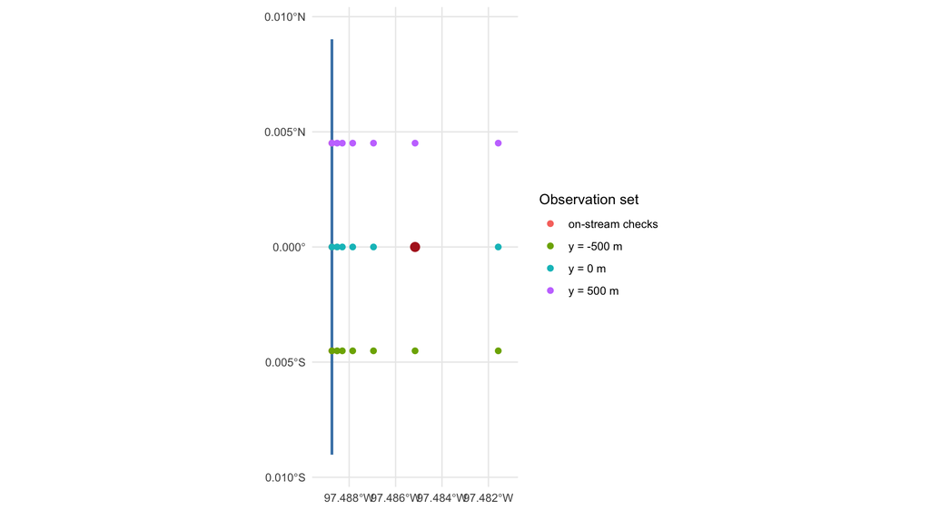

```r
on_stream <- tibble(
  observation_id = paste0("stream_y_", c("m500", "0", "p500")),
  transect = "on-stream checks",
  distance_from_stream = 0,
  x = 0,
  y = c(-500, 0, 500)
)

transects <- tidyr::expand_grid(
  transect_y = c(-500, 0, 500),
  distance_from_stream = c(0, 25, 50, 100, 200, 400, 800)
) |>
  mutate(
    observation_id = paste0("transect_", transect_y, "_x_", distance_from_stream),
    transect = paste0("y = ", transect_y, " m"),
    x = distance_from_stream,
    y = transect_y
  ) |>
  select(observation_id, transect, distance_from_stream, x, y)

observation_table <- bind_rows(on_stream, transects) |>
  distinct(observation_id, .keep_all = TRUE)

observation_wells <- st_as_sf(
  observation_table,
  coords = c("x", "y"),
  crs = analysis_crs
)

ggplot() +
  geom_sf(data = stream_reaches, color = "steelblue", linewidth = 1) +
  geom_sf(data = observation_wells, aes(color = transect), size = 1.8) +
  geom_sf(data = pumping_wells, color = "firebrick", size = 3) +
  coord_sf(xlim = c(-50, 850), ylim = c(-1050, 1050)) +
  labs(color = "Observation set") +
  theme_minimal()
```

## Run several stream-segment spacings

The target spacings below create progressively denser injection points. `sample_spacing` is kept at one quarter of `reach_spacing` so the stream-web apportionment is refined at the same time. The injection time grid is held fixed across runs, separating spatial from temporal sensitivity.

```r
segment_spacings <- c(200, 100, 50, 20, 10)

run_spacing <- function(spacing_m) {
  stream_apportionment <- get_stream_reach_apportionment(
    pumping_wells,
    stream_reaches,
    reach_spacing = set_units(spacing_m, "m"),
    sample_spacing = set_units(spacing_m / 4, "m"),
    method = "web_squared",
    analysis_crs = analysis_crs
  )

  drawdown <- get_apportioned_aquifer_drawdown(
    pumping_wells,
    pumping_schedules,
    observation_wells,
    stream_apportionment,
    evaluation_times,
    injection_times = injection_times
  )

  drawdown |>
    left_join(st_drop_geometry(observation_wells), by = "observation_id") |>
    mutate(
      segment_spacing_m = spacing_m,
      number_of_segments = n_distinct(stream_apportionment$reach_segment_id),
      aquifer_drawdown_m = drop_units(set_units(aquifer_drawdown, "m"))
    )
}

sensitivity_results <- bind_rows(lapply(segment_spacings, run_spacing))

sensitivity_results |>
  distinct(segment_spacing_m, number_of_segments)
```

```
#> # A tibble: 5 × 2
#>   segment_spacing_m number_of_segments
#>               <dbl>              <int>
#> 1               200                 10
#> 2               100                 20
#> 3                50                 40
#> 4                20                100
#> 5                10                200
```

## Inspect the stream boundary residual

Ideally, net drawdown is zero everywhere on a constant-head stream. This plot shows the modeled residual at fixed stream locations. Comparing curves reveals whether the result is converging as the stream representation is refined. A logarithmic y-axis separates the small positive residuals; zero itself cannot be displayed on this scale.

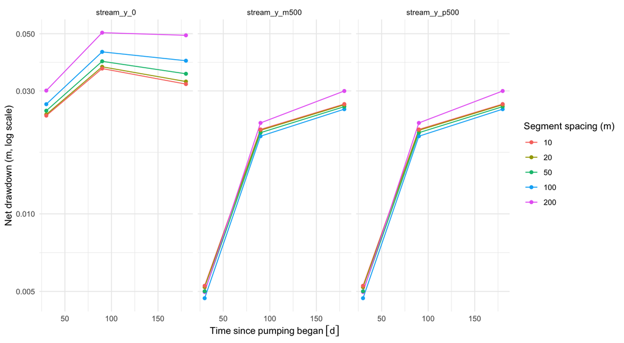

```r
sensitivity_results |>
  filter(transect == "on-stream checks") |>
  ggplot(aes(
    evaluation_time,
    aquifer_drawdown_m,
    color = factor(segment_spacing_m),
    group = segment_spacing_m
  )) +
  geom_line() +
  geom_point() +
  scale_y_log10() +
  facet_wrap(~observation_id) +
  labs(
    x = "Time since pumping began",
    y = "Net drawdown (m, log scale)",
    color = "Segment spacing (m)"
  ) +
  theme_minimal()
```

A compact diagnostic is the largest absolute on-stream residual for each scenario and evaluation time.

```r
stream_residual_summary <- sensitivity_results |>
  filter(transect == "on-stream checks") |>
  group_by(segment_spacing_m, number_of_segments, evaluation_time) |>
  summarize(
    maximum_absolute_residual_m = max(abs(aquifer_drawdown_m)),
    .groups = "drop"
  )

stream_residual_summary
```

```
#> # A tibble: 15 × 4
#>    segment_spacing_m number_of_segments evaluation_time maximum_absolute_resid…¹
#>                <dbl>              <int>             [d]                    <dbl>
#>  1                10                200              30                   0.0241
#>  2                10                200              90                   0.0366
#>  3                10                200             180                   0.0319
#>  4                20                100              30                   0.0243
#>  5                20                100              90                   0.0372
#>  6                20                100             180                   0.0326
#>  7                50                 40              30                   0.0251
#>  8                50                 40              90                   0.0391
#>  9                50                 40             180                   0.0350
#> 10               100                 20              30                   0.0266
#> 11               100                 20              90                   0.0425
#> 12               100                 20             180                   0.0393
#> 13               200                 10              30                   0.0301
#> 14               200                 10              90                   0.0505
#> 15               200                 10             180                   0.0493
#> # ℹ abbreviated name: ¹maximum_absolute_residual_m
```

## Inspect drawdown away from the stream

The transect profiles show how the modeled boundary residual relates to drawdown within the aquifer. The final evaluation time is used here for a readable spatial comparison. The pumping well lies at 400 m on the middle transect, so its finite physical diameter also prevents a point singularity. The logarithmic y-axis makes both the small near-stream response and larger drawdown near the pumping well visible in the same figure.

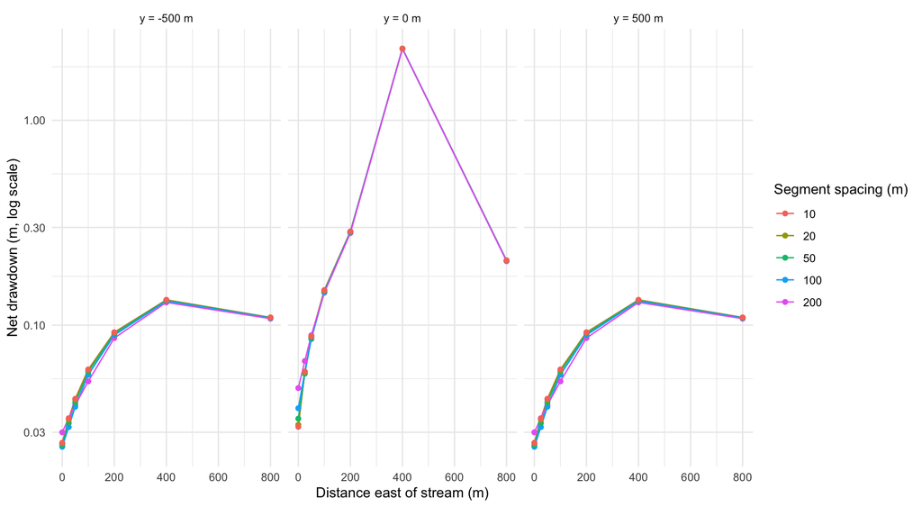

```r
final_time <- max(evaluation_times)

sensitivity_results |>
  filter(
    transect != "on-stream checks",
    evaluation_time == final_time
  ) |>
  ggplot(aes(
    distance_from_stream,
    aquifer_drawdown_m,
    color = factor(segment_spacing_m),
    group = segment_spacing_m
  )) +
  geom_line() +
  geom_point() +
  scale_y_log10() +
  facet_wrap(~transect) +
  labs(
    x = "Distance east of stream (m)",
    y = "Net drawdown (m, log scale)",
    color = "Segment spacing (m)"
  ) +
  theme_minimal()
```

## Interpretation

The effective injection diameter should be understood as a spatial regularization tied to the length represented by each point. It makes values at and near an injection point finite and makes the assumed support of the point response change consistently with segment density.

The most useful convergence checks are:

1. whether the maximum absolute on-stream residual decreases or stabilizes as segment spacing is reduced; and
2. whether the off-stream transect profiles become insensitive to further refinement.